# Covid-19 Project

2022-06-24

PACKAGES

```r
library(tidycensus)
library(tidyverse)
library(lubridate)
library(modelr)
library(tigris)
library(sf)
library(dplyr)

#census_api_key("INSERT_YOUR_API_KEY_HERE")

readRenviron("~/.Renviron")

options(tigris_use_cache = TRUE)
```

NYC Zipcodes

```r
nyc_zip_codes <- read_csv("https://raw.githubusercontent.com/erikgregorywebb/nyc-housing/master/Data/nyc-zip-codes.csv") %>%
  rename(GEOID = ZipCode)
```

# Getting and Filtering ACS Data

**Proportion of 18-64 year olds that are uninsured**

```r
nyc_uninsured <- get_acs(geography = "zcta",
                        variables = c(uninsured_34 = "B27010_033", uninsured_64 = "B27010_050", total_34 = "B27010_018", total_64 = "B27010_034"),
                        year = 2016,
                        geometry = TRUE) %>%
  select(GEOID:estimate) %>%
  filter(GEOID %in% nyc_zip_codes$GEOID) %>%
  pivot_wider(names_from = variable, values_from = estimate) %>%
  mutate(proportion_uninsured = (uninsured_34 + uninsured_64) / (total_34 + total_64))
```

**Median Income (in 2016 $)**

```r
nyc_med_income <- get_acs(geography = "zcta",
                         variables = c(medincome = "B19013_001"),
                         year = 2016,
                         geometry = TRUE) %>%
  select(GEOID:estimate) %>%
  filter(GEOID %in% nyc_zip_codes$GEOID) %>%
  mutate(median_income = estimate/1000000)
```

**Proportion of those self-identifying as White**

```r
nyc_prop_white <- get_acs(geography = "zcta",
                        variables = c(white_alone = "B02001_002", total = "B02001_001"),
                        year = 2016,
                        geometry = TRUE) %>%
  select(GEOID:estimate) %>%
  filter(GEOID %in% nyc_zip_codes$GEOID) %>%
  pivot_wider(names_from = variable, values_from = estimate) %>%
  mutate(proportion_white = white_alone/total)
```

**Proportion of 4- or more person households**

```r
nyc_prop4 <- get_acs(geography = "zcta",
                        variables = c(four = "B11016_005", five = "B11016_006", six = "B11016_007", seven_more = "B11016_008", nf_four = "B11016_013", nf_five = "B11016_014", nf_six = "B11016_015", nf_seven = "B11016_016", total = "B11016_001"),
                        year = 2016,
                        geometry = TRUE) %>%
  select(GEOID:estimate) %>%
  filter(GEOID %in% nyc_zip_codes$GEOID) %>%
  pivot_wider(names_from = variable, values_from = estimate) %>%
  mutate(proportion_4 = (four + five + six + seven_more + nf_four + nf_five + nf_six + nf_seven)/total)
```

**Proportion of those who ride buses**

```r
nyc_prop_bus <- get_acs(geography = "zcta",
                        variables = c(bus = 'B08301_011', total = "B08301_001"),
                        year = 2016,
                        geometry = TRUE) %>%
  select(GEOID:estimate) %>%
  filter(GEOID %in% nyc_zip_codes$GEOID) %>%
  pivot_wider(names_from = variable, values_from = estimate) %>%
  mutate(proportion_bus = bus/total)
```

**Proportion of Elderly (65+ years old)**

```r
nyc_prop_65yrs <- get_acs(geography = "zcta",
                         variables = c(m65 = "B01001_020", m67 = "B01001_021", m70 = "B01001_022", m75 = "B01001_023", m80 = "B01001_024", m85 = "B01001_025", f_65 = "B01001_044", f_67 = "B01001_045", f_70 = "B01001_046", f_75 = "B01001_047", f_80 = "B01001_048", f_85 = "B01001_049", total = "B01001_001"),
                         year = 2016,
                         geometry = TRUE) %>%
  select(GEOID:estimate) %>%
  filter(GEOID %in% nyc_zip_codes$GEOID) %>%
  pivot_wider(names_from = variable, values_from = estimate) %>%
  mutate(proportion_65 = (m65 + m67 + m70 + m75 + m80 + m85 + f_65 + f_67 + f_70 + f_75 + f_80 + f_85)/total)
```

# FIGURE 1

**Proportion of 18-64 year olds that are uninsured**

```r
nyc_uninsured %>%
  summary()
```

```
##     GEOID               NAME                    geometry    uninsured_34
##  Length:177         Length:177         MULTIPOLYGON :177   Min.   :    0
##  Class :character   Class :character   epsg:4269    :  0   1st Qu.:  793
##  Mode  :character   Mode  :character   +proj=long...:  0   Median : 1742
##                                                            Mean   : 2309
##                                                            3rd Qu.: 3204
##                                                            Max.   :16667
##
##   uninsured_64      total_34        total_64     proportion_uninsured
##  Min.   :    0   Min.   :    0   Min.   :    0   Min.   :0.00000
##  1st Qu.:  884   1st Qu.: 6697   1st Qu.:10974   1st Qu.:0.08763
##  Median : 1959   Median :11903   Median :16528   Median :0.13636
##  Mean   : 2504   Mean   :12978   Mean   :18232   Mean   :0.13969
##  3rd Qu.: 3373   3rd Qu.:18591   3rd Qu.:25786   3rd Qu.:0.17425
##  Max.   :15180   Max.   :36601   Max.   :42170   Max.   :0.43512
##                                                  NA's   :2
```

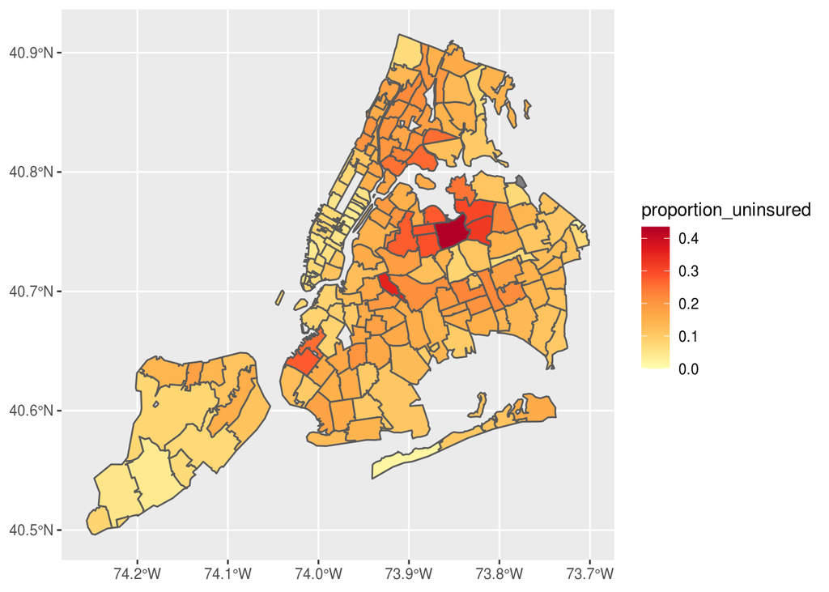

```r
ggplot(st_as_sf(nyc_uninsured), aes(fill = proportion_uninsured)) +
  geom_sf() +
  scale_fill_distiller(palette = "YlOrRd", direction = 1)
```

**Median Income**

```r
nyc_med_income %>%
  summary()
```

```
##     GEOID               NAME             variable            estimate
##  Length:177         Length:177         Length:177         Min.   : 21553
##  Class :character   Class :character   Class :character   1st Qu.: 45610
##  Mode  :character   Mode  :character   Mode  :character   Median : 59520
##                                                           Mean   : 65200
##                                                           3rd Qu.: 80392
##                                                           Max.   :234958
##                                                           NA's   :2
##           geometry   median_income
##  MULTIPOLYGON :177   Min.   :0.02155
##  epsg:4269    :  0   1st Qu.:0.04561
##  +proj=long...:  0   Median :0.05952
##                      Mean   :0.06520
##                      3rd Qu.:0.08039
##                      Max.   :0.23496
##                      NA's   :2
```

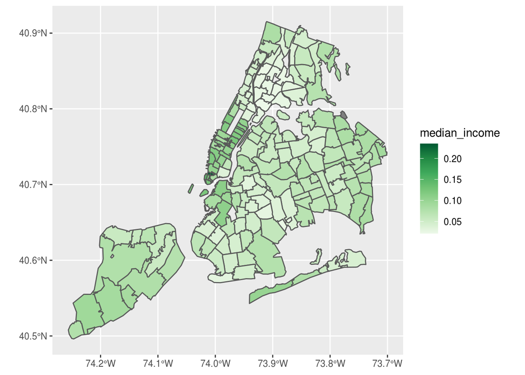

```r
ggplot(st_as_sf(nyc_med_income), aes(fill = median_income)) +
  geom_sf() +
  scale_fill_distiller(palette = "YlGr", direction = 1)
```

**Proportion of those self-identifying as white**

```r
nyc_prop_white %>%
  summary()
```

```
##     GEOID               NAME                    geometry    white_alone
##  Length:177         Length:177         MULTIPOLYGON :177   Min.   :    0
##  Class :character   Class :character   epsg:4269    :  0   1st Qu.: 7486
##  Mode  :character   Mode  :character   +proj=long...:  0   Median :15813
##                                                            Mean   :20512
##                                                            3rd Qu.:27547
##                                                            Max.   :85096
##
##      total        proportion_white
##  Min.   :     0   Min.   :0.02264
##  1st Qu.: 26739   1st Qu.:0.22622
##  Median : 43158   Median :0.48270
##  Mean   : 47675   Mean   :0.46694
##  3rd Qu.: 67822   3rd Qu.:0.69599
##  Max.   :112982   Max.   :0.99013
##                   NA's   :2
```

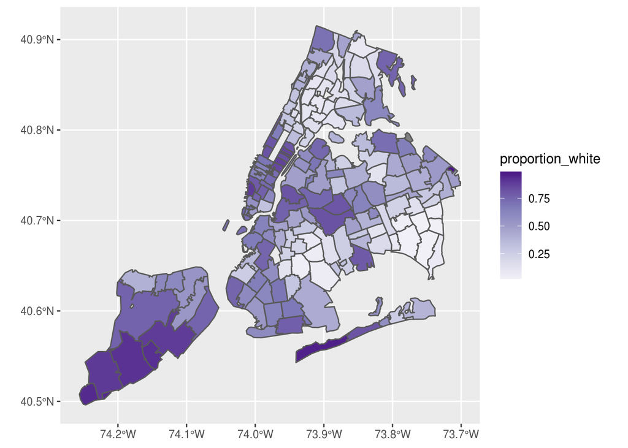

```r
ggplot(st_as_sf(nyc_prop_white), aes(fill = proportion_white)) +
  geom_sf() +
  scale_fill_distiller(palette = "Purples", direction = 1)
```

**Proportion of 4 or more person households**

```r
nyc_prop4 %>%
  summary()
```

```
##     GEOID               NAME                    geometry        four
##  Length:177         Length:177         MULTIPOLYGON :177   Min.   :   0
##  Class :character   Class :character   epsg:4269    :  0   1st Qu.:1074
##  Mode  :character   Mode  :character   +proj=long...:  0   Median :1916
##                                                            Mean   :2118
##                                                            3rd Qu.:3049
##                                                            Max.   :5653
##
##       five           six           seven_more        nf_four
##  Min.   :   0   Min.   :   0.0   Min.   :   0.0   Min.   :  0.00
##  1st Qu.: 418   1st Qu.: 134.0   1st Qu.:  70.0   1st Qu.:  9.00
##  Median : 871   Median : 325.0   Median : 211.0   Median : 38.00
##  Mean   :1048   Mean   : 444.8   Mean   : 375.9   Mean   : 66.33
##  3rd Qu.:1507   3rd Qu.: 677.0   3rd Qu.: 574.0   3rd Qu.: 87.00
##  Max.   :3464   Max.   :2084.0   Max.   :2874.0   Max.   :537.00
##
##     nf_five           nf_six           nf_seven          total
##  Min.   :  0.00   Min.   :  0.000   Min.   : 0.000   Min.   :    0
##  1st Qu.:  0.00   1st Qu.:  0.000   1st Qu.: 0.000   1st Qu.:10134
##  Median :  6.00   Median :  0.000   Median : 0.000   Median :16070
##  Mean   : 18.91   Mean   :  6.469   Mean   : 2.028   Mean   :17614
##  3rd Qu.: 25.00   3rd Qu.:  6.000   3rd Qu.: 0.000   3rd Qu.:25837
##  Max.   :180.00   Max.   :115.000   Max.   :34.000   Max.   :42783
##
##   proportion_4
##  Min.   :0.0000
##  1st Qu.:0.1494
##  Median :0.2441
##  Mean   :0.2343
##  3rd Qu.:0.3125
##  Max.   :0.5146
##  NA's   :2
```

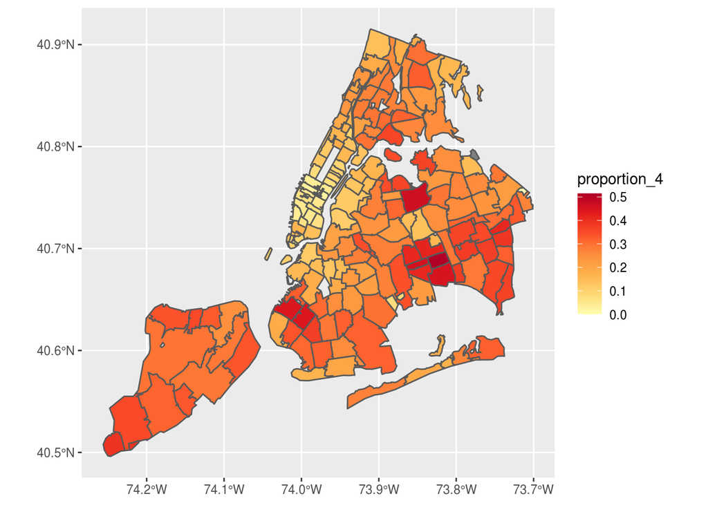

```r
ggplot(st_as_sf(nyc_prop4), aes(fill = proportion_4)) +
  geom_sf() +
  scale_fill_distiller(palette = "YlOrRd", direction = 1)
```

**Proportion of Bus Riders**

```r
nyc_prop_bus %>%
  summary()
```

```
##     GEOID               NAME                    geometry        bus
##  Length:177         Length:177         MULTIPOLYGON :177   Min.   :   0
##  Class :character   Class :character   epsg:4269    :  0   1st Qu.: 944
##  Mode  :character   Mode  :character   +proj=long...:  0   Median :1980
##                                                            Mean   :2392
##                                                            3rd Qu.:3479
##                                                            Max.   :9607
##
##      total       proportion_bus
##  Min.   :    0   Min.   :0.00000
##  1st Qu.:12811   1st Qu.:0.06479
##  Median :20247   Median :0.09612
##  Mean   :21952   Mean   :0.10911
##  3rd Qu.:31664   3rd Qu.:0.15018
##  Max.   :51837   Max.   :0.32354
##                  NA's   :2
```

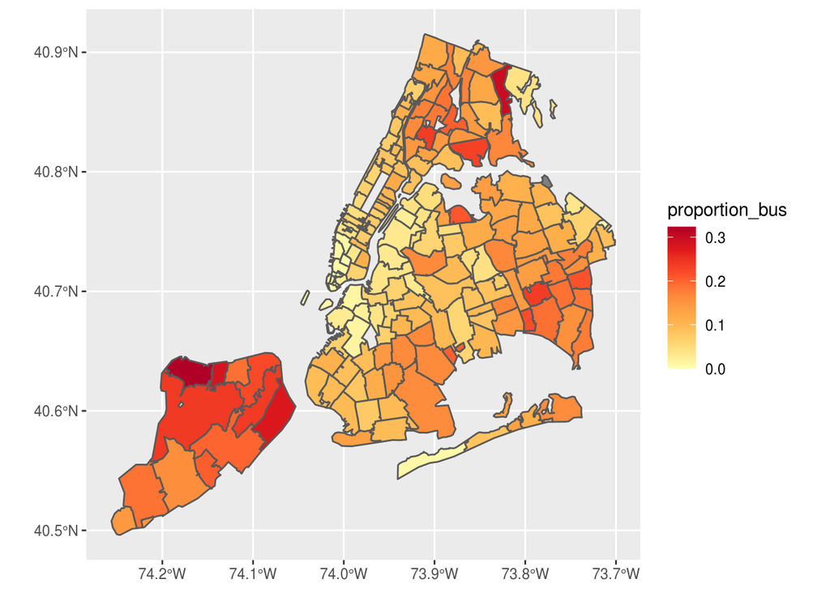

```r
ggplot(st_as_sf(nyc_prop_bus), aes(fill = proportion_bus)) +
  geom_sf() +
  scale_fill_distiller(palette = "YlOrRd", direction = 1)
```

**Proportion of Elderly**

```r
nyc_prop_65yrs %>%
  summary()
```

```
##     GEOID               NAME                    geometry        m65
##  Length:177         Length:177         MULTIPOLYGON :177   Min.   :   0.0
##  Class :character   Class :character   epsg:4269    :  0   1st Qu.: 214.0
##  Mode  :character   Mode  :character   +proj=long...:  0   Median : 359.0
##                                                            Mean   : 392.9
##                                                            3rd Qu.: 526.0
##                                                            Max.   :1195.0
##
##       m67            m70              m75              m80
##  Min.   :   0   Min.   :   0.0   Min.   :   0.0   Min.   :   0
##  1st Qu.: 258   1st Qu.: 330.0   1st Qu.: 246.0   1st Qu.: 147
##  Median : 461   Median : 567.0   Median : 391.0   Median : 249
##  Mean   : 478   Mean   : 621.7   Mean   : 442.9   Mean   : 302
##  3rd Qu.: 663   3rd Qu.: 831.0   3rd Qu.: 596.0   3rd Qu.: 414
##  Max.   :1356   Max.   :1617.0   Max.   :1225.0   Max.   :1176
##
##       m85              f_65             f_67           f_70
##  Min.   :   0.0   Min.   :   0.0   Min.   :   0   Min.   :   0
##  1st Qu.: 127.0   1st Qu.: 278.0   1st Qu.: 351   1st Qu.: 458
##  Median : 218.0   Median : 477.0   Median : 563   Median : 771
##  Mean   : 277.4   Mean   : 511.1   Mean   : 622   Mean   : 830
##  3rd Qu.: 376.0   3rd Qu.: 725.0   3rd Qu.: 875   3rd Qu.:1170
##  Max.   :1014.0   Max.   :1333.0   Max.   :1910   Max.   :2634
##
##       f_75             f_80             f_85            total
##  Min.   :   0.0   Min.   :   0.0   Min.   :   0.0   Min.   :     0
##  1st Qu.: 320.0   1st Qu.: 250.0   1st Qu.: 311.0   1st Qu.: 26739
##  Median : 541.0   Median : 436.0   Median : 514.0   Median : 43158
##  Mean   : 624.2   Mean   : 490.4   Mean   : 606.6   Mean   : 47675
##  3rd Qu.: 879.0   3rd Qu.: 716.0   3rd Qu.: 826.0   3rd Qu.: 67822
##  Max.   :2088.0   Max.   :1406.0   Max.   :2037.0   Max.   :112982
##
##  proportion_65
##  Min.   :0.0000
##  1st Qu.:0.1056
##  Median :0.1251
##  Mean   :0.1376
##  3rd Qu.:0.1604
##  Max.   :0.8723
##  NA's   :2
```

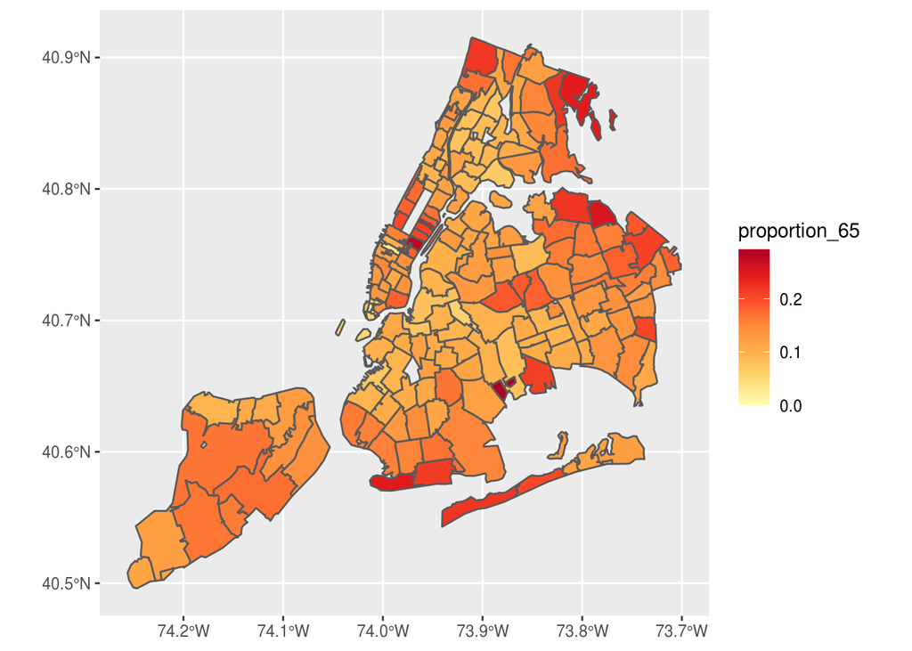

```r
nyc_prop_65yrs_filtered <- nyc_prop_65yrs %>%
  filter(proportion_65 < 0.8)


ggplot(st_as_sf(nyc_prop_65yrs_filtered), aes(fill = proportion_65)) +
  geom_sf() +
  scale_fill_distiller(palette = "YlOrRd", direction = 1)
```

# TABLE 1

```r
april_1 <- read_csv("https://raw.githubusercontent.com/nychealth/coronavirus-data/097cbd70aa00eb635b17b177bc4546b2fce21895/tests-by-zcta.csv") %>%
  mutate(pos_prop = Positive/Total) %>%
  rename(GEOID = MODZCTA) %>%
  select(GEOID, Positive:pos_prop)
```

*To Verify the # of April Tests and Positive Results*

```r
may_1 <- read_csv("https://raw.githubusercontent.com/nychealth/coronavirus-data/9e26adc2c475d3378d7579e48e936f8a807b254b/tests-by-zcta.csv") %>%
  rename(GEOID = MODZCTA)
twomonths_covid <- inner_join(april_1, may_1, by = "GEOID")

april_covid <- twomonths_covid %>%
  mutate(Positive = Positive.y - Positive.x, Total = Total.y - Total.x)

april_covid %>%
  summarize(positive = sum(Positive),
            total = sum(Total))
```

```
## # A tibble: 1 × 2
##   positive  total
##      <dbl>  <dbl>
## 1   125594 279266
```

*Merged Dataframes*

```r
df_list <- list(nyc_uninsured, nyc_med_income, nyc_prop_white, nyc_prop4, nyc_prop_bus, nyc_prop_65yrs)

all_df <- df_list %>%
  reduce(full_join, by = "GEOID") %>%
  select(GEOID, proportion_uninsured, median_income, proportion_white, proportion_4, proportion_bus, proportion_65)

lm_all <- merge(all_df, april_1, by = "GEOID") %>%
  select(GEOID, proportion_uninsured:pos_prop)
```

*Univariate Linear Models*

**Proportion of 4-Person Household**

```r
lmfit_4 <- lm(pos_prop ~ proportion_4, data = lm_all)

summary(lmfit_4)
```

```
##
## Call:
## lm(formula = pos_prop ~ proportion_4, data = lm_all)
##
## Residuals:
##       Min        1Q    Median        3Q       Max
## -0.183441 -0.049585  0.004482  0.045944  0.230288
##
## Coefficients:
##              Estimate Std. Error t value Pr(>|t|)
## (Intercept)   0.38622    0.01360   28.39   <2e-16 ***
## proportion_4  0.54103    0.05261   10.28   <2e-16 ***
## ---
## Signif. codes:  0 '***' 0.001 '**' 0.01 '*' 0.05 '.' 0.1 ' ' 1
##
## Residual standard error: 0.07386 on 172 degrees of freedom
## Multiple R-squared:  0.3808, Adjusted R-squared:  0.3772
## F-statistic: 105.8 on 1 and 172 DF,  p-value: < 2.2e-16
```

**Proportion of People 18-64 Years Old that are Uninsured**

```r
lmfit_uninsured <- lm(pos_prop ~ proportion_uninsured, data = lm_all)

summary(lmfit_uninsured)
```

```
##
## Call:
## lm(formula = pos_prop ~ proportion_uninsured, data = lm_all)
##
## Residuals:
##      Min       1Q   Median       3Q      Max
## -0.19589 -0.05091 -0.00009  0.04891  0.19165
##
## Coefficients:
##                      Estimate Std. Error t value Pr(>|t|)
## (Intercept)           0.40055    0.01323  30.285   <2e-16 ***
## proportion_uninsured  0.80543    0.08473   9.506   <2e-16 ***
## ---
## Signif. codes:  0 '***' 0.001 '**' 0.01 '*' 0.05 '.' 0.1 ' ' 1
##
## Residual standard error: 0.076 on 172 degrees of freedom
## Multiple R-squared:  0.3444, Adjusted R-squared:  0.3406
## F-statistic: 90.36 on 1 and 172 DF,  p-value: < 2.2e-16
```

**Proportion Self-Identifying as White**

```r
lmfit_white <- lm(pos_prop ~ proportion_white, data = lm_all)

summary(lmfit_white)
```

```
##
## Call:
## lm(formula = pos_prop ~ proportion_white, data = lm_all)
##
## Residuals:
##       Min        1Q    Median        3Q       Max
## -0.223365 -0.050350 -0.003711  0.049074  0.248037
##
## Coefficients:
##                  Estimate Std. Error t value Pr(>|t|)
## (Intercept)       0.60930    0.01180  51.625   <2e-16 ***
## proportion_white -0.20604    0.02215  -9.301   <2e-16 ***
## ---
## Signif. codes:  0 '***' 0.001 '**' 0.01 '*' 0.05 '.' 0.1 ' ' 1
##
## Residual standard error: 0.07656 on 172 degrees of freedom
## Multiple R-squared:  0.3347, Adjusted R-squared:  0.3308
## F-statistic: 86.52 on 1 and 172 DF,  p-value: < 2.2e-16
```

**Median Income**

```r
lmfit_med <- lm(pos_prop ~ median_income, data = lm_all)

summary(lmfit_med)
```

```
##
## Call:
## lm(formula = pos_prop ~ median_income, data = lm_all)
##
## Residuals:
##       Min        1Q    Median        3Q       Max
## -0.157240 -0.051246 -0.005256  0.046963  0.223152
##
## Coefficients:
##               Estimate Std. Error t value Pr(>|t|)
## (Intercept)    0.63219    0.01413  44.730   <2e-16 ***
## median_income -1.81684    0.19747  -9.201   <2e-16 ***
## ---
## Signif. codes:  0 '***' 0.001 '**' 0.01 '*' 0.05 '.' 0.1 ' ' 1
##
## Residual standard error: 0.07684 on 172 degrees of freedom
## Multiple R-squared:  0.3298, Adjusted R-squared:  0.3259
## F-statistic: 84.65 on 1 and 172 DF,  p-value: < 2.2e-16
```

**Proportion of People Who Commute by Bus**

```r
lmfit_bus <- lm(pos_prop ~ proportion_bus, data = lm_all)

summary(lmfit_bus)
```

```
##
## Call:
## lm(formula = pos_prop ~ proportion_bus, data = lm_all)
##
## Residuals:
##      Min       1Q   Median       3Q      Max
## -0.21164 -0.05939  0.00531  0.06316  0.25421
##
## Coefficients:
##                Estimate Std. Error t value Pr(>|t|)
## (Intercept)     0.45900    0.01324  34.673  < 2e-16 ***
## proportion_bus  0.49858    0.10412   4.788 3.61e-06 ***
## ---
## Signif. codes:  0 '***' 0.001 '**' 0.01 '*' 0.05 '.' 0.1 ' ' 1
##
## Residual standard error: 0.08817 on 172 degrees of freedom
## Multiple R-squared:  0.1176, Adjusted R-squared:  0.1125
## F-statistic: 22.93 on 1 and 172 DF,  p-value: 3.609e-06
```

**Proportion Elderly (65+ years)**

```r
lmfit_65yrs <- lm(pos_prop ~ proportion_65, data = lm_all)

summary(lmfit_65yrs)
```

```
##
## Call:
## lm(formula = pos_prop ~ proportion_65, data = lm_all)
##
## Residuals:
##       Min        1Q    Median        3Q       Max
## -0.307230 -0.061731  0.009153  0.058078  0.242477
##
## Coefficients:
##               Estimate Std. Error t value Pr(>|t|)
## (Intercept)    0.55723    0.02118  26.306   <2e-16 ***
## proportion_65 -0.32624    0.14982  -2.178   0.0308 *
## ---
## Signif. codes:  0 '***' 0.001 '**' 0.01 '*' 0.05 '.' 0.1 ' ' 1
##
## Residual standard error: 0.0926 on 172 degrees of freedom
## Multiple R-squared:  0.02683,    Adjusted R-squared:  0.02117
## F-statistic: 4.742 on 1 and 172 DF,  p-value: 0.0308
```

*Multivariate Linear Models (Table 1)*

**4 variables: 4 or more people, uninsured, white, median income**

```r
lmfit_best <- lm(pos_prop ~ proportion_4 + proportion_uninsured + proportion_white + median_income, data = lm_all)

summary(lmfit_best)
```

```
##
## Call:
## lm(formula = pos_prop ~ proportion_4 + proportion_uninsured +
##     proportion_white + median_income, data = lm_all)
##
## Residuals:
##       Min        1Q    Median        3Q       Max
## -0.149488 -0.041478  0.000718  0.035394  0.171808
##
## Coefficients:
##                      Estimate Std. Error t value Pr(>|t|)
## (Intercept)           0.47773    0.02872  16.632  < 2e-16 ***
## proportion_4          0.31606    0.05403   5.849 2.49e-08 ***
## proportion_uninsured  0.23732    0.10211   2.324  0.02131 *
## proportion_white     -0.08152    0.02437  -3.345  0.00101 **
## median_income        -0.52172    0.24451  -2.134  0.03431 *
## ---
## Signif. codes:  0 '***' 0.001 '**' 0.01 '*' 0.05 '.' 0.1 ' ' 1
##
## Residual standard error: 0.06345 on 169 degrees of freedom
## Multiple R-squared:  0.5511, Adjusted R-squared:  0.5404
## F-statistic: 51.86 on 4 and 169 DF,  p-value: < 2.2e-16
```

# FIGURE 2: MOBILITY DATA

*Safegraph Data*

```r
load('/data/safegraph/safegraph.Rdata')

safegraph <- safegraph %>%
  rename(GEOID = postal_code) %>%
  merge(nyc_zip_codes, by = "GEOID")
```

*February*

```r
february <- safegraph %>%
  filter(month(date)==2) %>%
  arrange(GEOID, date)
```

```r
med_feb <- february %>%
  group_by(GEOID) %>%
  summarize(median = median(avg_visits_per_day))
```

*March & April*

```r
mar_apr <- safegraph %>%
  filter(month(date)==3 | month(date)==4) %>%
  arrange(GEOID, date)
```

*Change in Mobility Calculations*

```r
mobility <- merge(mar_apr, med_feb, by = "GEOID") %>%
  mutate(change = (avg_visits_per_day-median)/median)

mob_summary <- mobility %>%
  group_by(date) %>%
  summarize(q1 = quantile(change, probs = 0.25, na.rm = TRUE),
            q3 = quantile(change, probs = 0.75, na.rm = TRUE),
            med = quantile(change, probs = 0.5, na.rm = TRUE))


mobility_filter <- mobility %>%
  filter(abs(change) < 1)
```

**Violin Plot (filtered)**

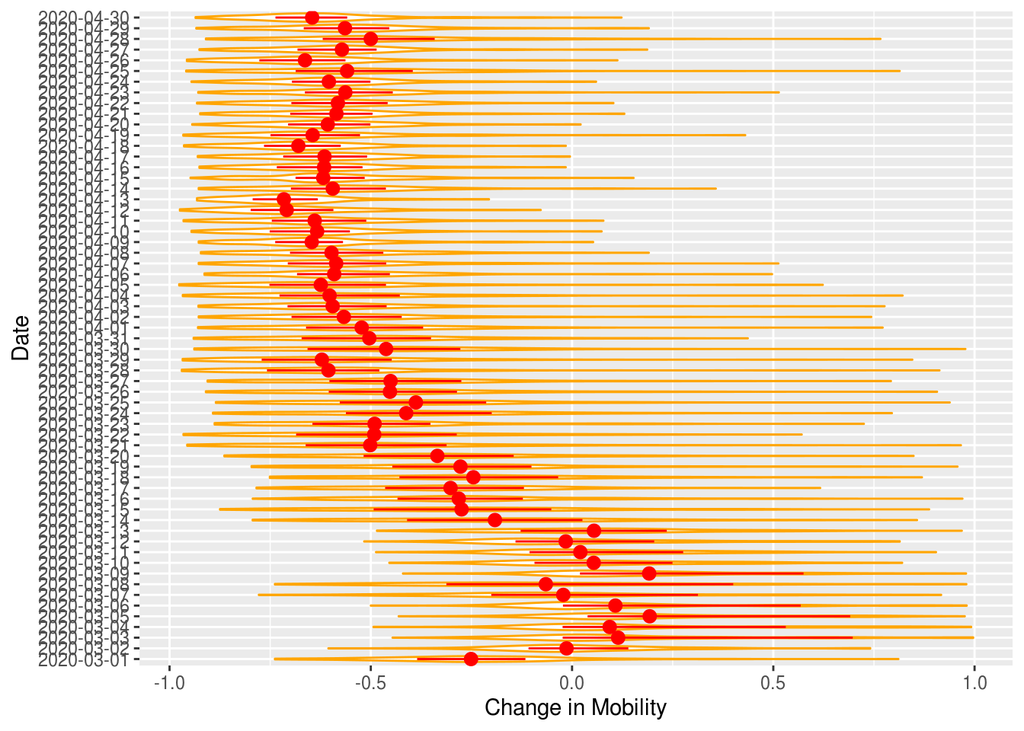

```r
ggplot() +
  geom_violin(data = mobility_filter, aes(x = as.factor(date), y = change), color = "Orange") +
  geom_pointrange(data = mob_summary, aes(x = as.factor(date), y = med, ymin = q1, ymax = q3), color = "Red") +
  coord_flip() +
  ylab("Change in Mobility") +
  xlab("Date")
```

# TABLE 2

```r
all_variables <- merge(lm_all, mobility, by = "GEOID") %>%
  filter(is.finite(change), date == "2020-04-01")
```

*Univariate Linear Model (Mobility)*

```r
lm_mobility <- lm(pos_prop ~ change, data = all_variables)

lm_mobility %>%
  summary()
```

```
##
## Call:
## lm(formula = pos_prop ~ change, data = all_variables)
##
## Residuals:
##       Min        1Q    Median        3Q       Max
## -0.238617 -0.069295  0.009215  0.063818  0.258758
##
## Coefficients:
##             Estimate Std. Error t value Pr(>|t|)
## (Intercept)  0.54428    0.01236  44.025  < 2e-16 ***
## change       0.06458    0.02127   3.036  0.00278 **
## ---
## Signif. codes:  0 '***' 0.001 '**' 0.01 '*' 0.05 '.' 0.1 ' ' 1
##
## Residual standard error: 0.09177 on 168 degrees of freedom
## Multiple R-squared:  0.05202,    Adjusted R-squared:  0.04638
## F-statistic: 9.219 on 1 and 168 DF,  p-value: 0.002777
```

*Multivariate Linear Model (Table 2)*

All Variables (Except Mobility)

```r
lm_no_mobility <- lm(pos_prop ~ proportion_65 + proportion_bus + median_income + proportion_white + proportion_uninsured + proportion_4, data = all_variables)

lm_no_mobility %>%
  summary()
```

```
##
## Call:
## lm(formula = pos_prop ~ proportion_65 + proportion_bus + median_income +
##     proportion_white + proportion_uninsured + proportion_4, data = all_variables)
##
## Residuals:
##       Min        1Q    Median        3Q       Max
## -0.128352 -0.040821  0.002825  0.036313  0.161894
##
## Coefficients:
##                      Estimate Std. Error t value Pr(>|t|)
## (Intercept)           0.45964    0.03708  12.395  < 2e-16 ***
## proportion_65         0.20431    0.11900   1.717 0.087898 .
## proportion_bus       -0.12890    0.10337  -1.247 0.214192
## median_income        -0.53292    0.25746  -2.070 0.040037 *
## proportion_white     -0.09442    0.02591  -3.644 0.000361 ***
## proportion_uninsured  0.25120    0.11410   2.202 0.029104 *
## proportion_4          0.35457    0.06498   5.457 1.77e-07 ***
## ---
## Signif. codes:  0 '***' 0.001 '**' 0.01 '*' 0.05 '.' 0.1 ' ' 1
##
## Residual standard error: 0.0631 on 163 degrees of freedom
## Multiple R-squared:  0.5652, Adjusted R-squared:  0.5492
## F-statistic: 35.31 on 6 and 163 DF,  p-value: < 2.2e-16
```

All Variables (with Mobility)

```r
lm_table2 <- lm(pos_prop ~ proportion_65 + proportion_bus + median_income + proportion_white + proportion_uninsured + proportion_4 + change, data = all_variables)

lm_table2 %>%
  summary()
```

```
##
## Call:
## lm(formula = pos_prop ~ proportion_65 + proportion_bus + median_income +
##     proportion_white + proportion_uninsured + proportion_4 +
##     change, data = all_variables)
##
## Residuals:
##       Min        1Q    Median        3Q       Max
## -0.129691 -0.040282  0.001171  0.038038  0.161209
##
## Coefficients:
##                      Estimate Std. Error t value Pr(>|t|)
## (Intercept)           0.45130    0.03827  11.794  < 2e-16 ***
## proportion_65         0.20374    0.11907   1.711  0.08900 .
## proportion_bus       -0.12332    0.10363  -1.190  0.23579
## median_income        -0.56699    0.26043  -2.177  0.03092 *
## proportion_white     -0.09319    0.02597  -3.589  0.00044 ***
## proportion_uninsured  0.25391    0.11421   2.223  0.02759 *
## proportion_4          0.36414    0.06590   5.526 1.28e-07 ***
## change               -0.01424    0.01596  -0.893  0.37335
## ---
## Signif. codes:  0 '***' 0.001 '**' 0.01 '*' 0.05 '.' 0.1 ' ' 1
##
## Residual standard error: 0.06314 on 162 degrees of freedom
## Multiple R-squared:  0.5673, Adjusted R-squared:  0.5486
## F-statistic: 30.34 on 7 and 162 DF,  p-value: < 2.2e-16
```